# ECo 602 - Analysis of Environmental Data

Final Project: Data Analysis

Lucy Cousins

Fall 2020

# Introduction

During the Fall 2020 semester, I learned about R and it’s applications in data science in ECo 602. My knowledge grew substantially in topics ranging from deterministic functions to linear models to frequentist concepts. Here is an amalgamation of what I learned!

*Note that the answers to the questions are at the vey bottom of the page.

# Subsetting Operators and Functions

## [ ]

The hard brackets can be used to specify a column by index. This is useful if you do not know the name of a column, but you *do* know where it is relative to the others.

```r
require(palmerpenguins)

# Subsetting the third column of palmerpenguins
penguins[3]
```

```
## # A tibble: 344 x 1
##    bill_length_mm
##             <dbl>
##  1           39.1
##  2           39.5
##  3           40.3
##  4           NA
##  5           36.7
##  6           39.3
##  7           38.9
##  8           39.2
##  9           34.1
## 10           42
## # … with 334 more rows
```

## $

The dollar sign can be used if you know the name of a column, but not the index. It is useful if other people (who may not be as familiar with the data as you) will be reading your code. Also, it is useful because you may not always remember what numbers correspond to what columns.

```r
penguins$bill_length_mm
```

```
##   [1] 39.1 39.5 40.3   NA 36.7 39.3 38.9 39.2 34.1 42.0 37.8 37.8 41.1 38.6
##  [15] 34.6 36.6 38.7 42.5 34.4 46.0 37.8 37.7 35.9 38.2 38.8 35.3 40.6 40.5
##  [29] 37.9 40.5 39.5 37.2 39.5 40.9 36.4 39.2 38.8 42.2 37.6 39.8 36.5 40.8
##  [43] 36.0 44.1 37.0 39.6 41.1 37.5 36.0 42.3 39.6 40.1 35.0 42.0 34.5 41.4
##  [57] 39.0 40.6 36.5 37.6 35.7 41.3 37.6 41.1 36.4 41.6 35.5 41.1 35.9 41.8
##  [71] 33.5 39.7 39.6 45.8 35.5 42.8 40.9 37.2 36.2 42.1 34.6 42.9 36.7 35.1
##  [85] 37.3 41.3 36.3 36.9 38.3 38.9 35.7 41.1 34.0 39.6 36.2 40.8 38.1 40.3
##  [99] 33.1 43.2 35.0 41.0 37.7 37.8 37.9 39.7 38.6 38.2 38.1 43.2 38.1 45.6
## [113] 39.7 42.2 39.6 42.7 38.6 37.3 35.7 41.1 36.2 37.7 40.2 41.4 35.2 40.6
## [127] 38.8 41.5 39.0 44.1 38.5 43.1 36.8 37.5 38.1 41.1 35.6 40.2 37.0 39.7
## [141] 40.2 40.6 32.1 40.7 37.3 39.0 39.2 36.6 36.0 37.8 36.0 41.5 46.1 50.0
## [155] 48.7 50.0 47.6 46.5 45.4 46.7 43.3 46.8 40.9 49.0 45.5 48.4 45.8 49.3
## [169] 42.0 49.2 46.2 48.7 50.2 45.1 46.5 46.3 42.9 46.1 44.5 47.8 48.2 50.0
## [183] 47.3 42.8 45.1 59.6 49.1 48.4 42.6 44.4 44.0 48.7 42.7 49.6 45.3 49.6
## [197] 50.5 43.6 45.5 50.5 44.9 45.2 46.6 48.5 45.1 50.1 46.5 45.0 43.8 45.5
## [211] 43.2 50.4 45.3 46.2 45.7 54.3 45.8 49.8 46.2 49.5 43.5 50.7 47.7 46.4
## [225] 48.2 46.5 46.4 48.6 47.5 51.1 45.2 45.2 49.1 52.5 47.4 50.0 44.9 50.8
## [239] 43.4 51.3 47.5 52.1 47.5 52.2 45.5 49.5 44.5 50.8 49.4 46.9 48.4 51.1
## [253] 48.5 55.9 47.2 49.1 47.3 46.8 41.7 53.4 43.3 48.1 50.5 49.8 43.5 51.5
## [267] 46.2 55.1 44.5 48.8 47.2   NA 46.8 50.4 45.2 49.9 46.5 50.0 51.3 45.4
## [281] 52.7 45.2 46.1 51.3 46.0 51.3 46.6 51.7 47.0 52.0 45.9 50.5 50.3 58.0
## [295] 46.4 49.2 42.4 48.5 43.2 50.6 46.7 52.0 50.5 49.5 46.4 52.8 40.9 54.2
## [309] 42.5 51.0 49.7 47.5 47.6 52.0 46.9 53.5 49.0 46.2 50.9 45.5 50.9 50.8
## [323] 50.1 49.0 51.5 49.8 48.1 51.4 45.7 50.7 42.5 52.2 45.2 49.3 50.2 45.6
## [337] 51.9 46.8 45.7 55.8 43.5 49.6 50.8 50.2
```

## subset()

The subset function is useful if you have specific parameters for data that you need in a column. It allows for a lot of freedom while subsetting.

```r
subset(penguins,  bill_length_mm < 190)
```

```
## # A tibble: 342 x 8
##    species island bill_length_mm bill_depth_mm flipper_length_… body_mass_g
##    <fct>   <fct>           <dbl>         <dbl>            <int>       <int>
##  1 Adelie  Torge…           39.1          18.7              181        3750
##  2 Adelie  Torge…           39.5          17.4              186        3800
##  3 Adelie  Torge…           40.3          18                195        3250
##  4 Adelie  Torge…           36.7          19.3              193        3450
##  5 Adelie  Torge…           39.3          20.6              190        3650
##  6 Adelie  Torge…           38.9          17.8              181        3625
##  7 Adelie  Torge…           39.2          19.6              195        4675
##  8 Adelie  Torge…           34.1          18.1              193        3475
##  9 Adelie  Torge…           42            20.2              190        4250
## 10 Adelie  Torge…           37.8          17.1              186        3300
## # … with 332 more rows, and 2 more variables: sex <fct>, year <int>
```

# Functions 1: Data Structure Functions

The code:

{.tabset .tabset-pills}

creates tabbed content for all the following sections that are one-level below.

- If you include them on a primary header (one #), all of the subsequent secondary headers will in tabs.

## `c()`

The function `c()` *combines* or *concatenates* its arguments into a vector (a 1-dimensional data structure consisting of 1 or more elements).

- If the vector is atomic, all of the elements should be the same data type.

Here are two examples using numeric and character/string data types:

```r
# Create a vector of numbers:
num_vec  = c(1, 4, 8, 9, 13)

# Create a vector of characters/strings:
char_vec = c("a", "fish", "data is cool")
```

I can show the contents of a vector by typing the name of the vector, or using the `print()` function.

```r
# Typing the name of the vector into the console prints the contents
num_vec
```

```
## [1]  1  4  8  9 13
```

```r
# The print() function accomplishes the same task:
print(char_vec)
```

```
## [1] "a"            "fish"         "data is cool"
```

## `data.frame()`

How to subset a data frame:

- If I know the name of a column, I can use the $ sign
- Alternatively, if I know the *index* of the column, I can put the number inside hard brackets [ ]. If you want the first column, use the number 1, and so on.

```r
#build a dataframe from scratch
dat_1 = data.frame(
  letters = c("b", "w", "B"),
  numbers_1 = c(34, 6, 123454)
  )
#  I can print the contents by typing the name of the data frame
dat_1
```

```
##   letters numbers_1
## 1       b        34
## 2       w         6
## 3       B    123454
```

```r
#subset a column by name
dat_1$letters
```

```
## [1] b w B
## Levels: b B w
```

```r
#subset a column by index
dat_1[1]
```

```
##   letters
## 1       b
## 2       w
## 3       B
```

## `matrix()`

The following code creates a matrix with 2 rows and 3 columns. A matrix can be thought of as a multidimensional vector.

- You can specify a vector in the first argument.
- Then you can specify how many rows (`nrow =`) and columns (`ncol =`))
- After that, you can use the parameter `byrow` to specify which diriection you want the numbers to increase.
  - if `byrow = TRUE`, then the numbers will increase along columns in the horizontal direction, and then wrap to the next row when there are no more columns.
  - if `byrow = FALSE`, then the numbers will increase down the columns in the vertical direction until there are no more rows, which is when it will wrap to the next column.

```r
# This is how you create a matrix
matrix_1 = matrix(c(1,2,3,4,5,6), nrow=2, ncol=3, byrow = TRUE)
matrix_1a = matrix(c(1,2,3,4,5,6), nrow=2, ncol=3, byrow = FALSE)

# I can print the contents of the matrix by simply typing the variable name
matrix_1
```

```
##      [,1] [,2] [,3]
## [1,]    1    2    3
## [2,]    4    5    6
```

```r
matrix_1a
```

```
##      [,1] [,2] [,3]
## [1,]    1    3    5
## [2,]    2    4    6
```

```r
# If I want to subset the matrix, maybe by only printing the second row, I would use the following code
matrix_1[2, ]
```

```
## [1] 4 5 6
```

```r
#I can use a similar approach to subset by column, but this time I would put the number after the comma
matrix_1[ ,2]
```

```
## [1] 2 5
```

## `length()`

The length function returns ths length of any object in R. The only required parameter is the object you want to find the length of. The length can be thought of as the number of elements within that object, like the number of elements in a vector. This is particularly helpful for very long objects, such as a column in a csv file.

```r
#Finding the length of the dataframe created earlier
length(dat_1)
```

```
## [1] 2
```

```r
#Finding the length of the matrix
length(matrix_1)
```

```
## [1] 6
```

```r
#Finding the length of the elev column in palmerpenguins
#load the penguins package
require(palmerpenguins)
length(penguins$bill_length_mm)
```

```
## [1] 344
```

## `nrow()`

`nrow()` tells you how many rows a dataframe or matrix has. It’s a good way to get a sense of how big the data set is if you don’t already know. This can be useful when you need to check if a matrix can be multiplied by another matrix, for example, or if you just want to do some data exploration.

```r
#rows in penguins
nrow(penguins)
```

```
## [1] 344
```

```r
#rows in matrix_1
nrow(matrix_1)
```

```
## [1] 2
```

## `ncol()`

`ncol()` tells you how many columns a dataframe has. This can be useful when you need to check if a matrix can be multiplied by another matrix, for example, or if you just want to do some data exploration.

```r
#columns in penguins
ncol(penguins)
```

```
## [1] 8
```

```r
#columns in matrix_1
ncol(matrix_1)
```

```
## [1] 3
```

## `dim()`

`dim()` will provide the dimensions of a dataframe or matrix. The first number in the output is the number of rows, the second is the number of columns.

```r
# dimensions of penguins
dim(penguins)
```

```
## [1] 344   8
```

```r
#dimensions of matrix_1
dim(matrix_1)
```

```
## [1] 2 3
```

# Functions 2: Numerical Data Exploration

## `summary()`

The `summary()` function displays summary information about a dataset. It is extremely useful for getting a general idea about the shape/size of the dataset. The informaiton displayed includes:

- categorical variables and the counts of each
- minimum, 1st quartile, median, mean, 3rd quartile, maximum and the number of NA values.

```r
summary(penguins)
```

```
##       species          island    bill_length_mm  bill_depth_mm
##  Adelie   :152   Biscoe   :168   Min.   :32.10   Min.   :13.10
##  Chinstrap: 68   Dream    :124   1st Qu.:39.23   1st Qu.:15.60
##  Gentoo   :124   Torgersen: 52   Median :44.45   Median :17.30
##                                  Mean   :43.92   Mean   :17.15
##                                  3rd Qu.:48.50   3rd Qu.:18.70
##                                  Max.   :59.60   Max.   :21.50
##                                  NA's   :2       NA's   :2
##  flipper_length_mm  body_mass_g       sex           year
##  Min.   :172.0     Min.   :2700   female:165   Min.   :2007
##  1st Qu.:190.0     1st Qu.:3550   male  :168   1st Qu.:2007
##  Median :197.0     Median :4050   NA's  : 11   Median :2008
##  Mean   :200.9     Mean   :4202                Mean   :2008
##  3rd Qu.:213.0     3rd Qu.:4750                3rd Qu.:2009
##  Max.   :231.0     Max.   :6300                Max.   :2009
##  NA's   :2         NA's   :2
```

## `mean()`

The `mean()` function returns the average of a numerical variable.

**Note:** if there are any NA values in the column, the mean will be `NA`, so be sure to tell the function to ignore those values in the parameters list using `na.rm=TRUE`.

```r
# This is without removing NAs
mean(penguins$flipper_length_mm)
```

```
## [1] NA
```

```r
# This is with removing NAs
mean(penguins$flipper_length_mm, na.rm=TRUE)
```

```
## [1] 200.9152
```

## `sd()`

The `sd()` function returns the standard deviation of a numerical column. There are a couple of important things to note about this:

- The standard deviation is the average distance of points to the mean. It tells you how spread out the data is.
- If the data is not normally distributed, the standard deviation may not be the best way to represent the spread of the data. Be careful to check the distribution using a histogram and/or using a scatterplot of the residual values.
- Don’t forget to use `na.rm=TRUE`!

```r
sd(penguins$flipper_length_mm, na.rm=TRUE)
```

```
## [1] 14.06171
```

# Functions 3: Graphical Data Exploration

## `plot()`

I can use `plot()` to create scatterplots!

- The first argument is the column/formula that you want to plot
- If you don’t use the $ sign in the first argument, you must use the `data =` argument, which is simply the name of the dataset that you want to plot.
- I can use the `pch =` argument to change the symbol in the plot
- The `col =` argument specifies the color of the marks. It can be used to create a uniform color scheme across a .rmd document, or if you want to display multiple colors on one graph.
- The parameter `cex =` is used to specify how magnified the points are. If you have many points, it might make sense to make them smaller. 1 is the default.
- The `xlim =` and `ylim =` arguments specify the bounds of the plot. You must use a vector for this parameter in the form c(min, max).

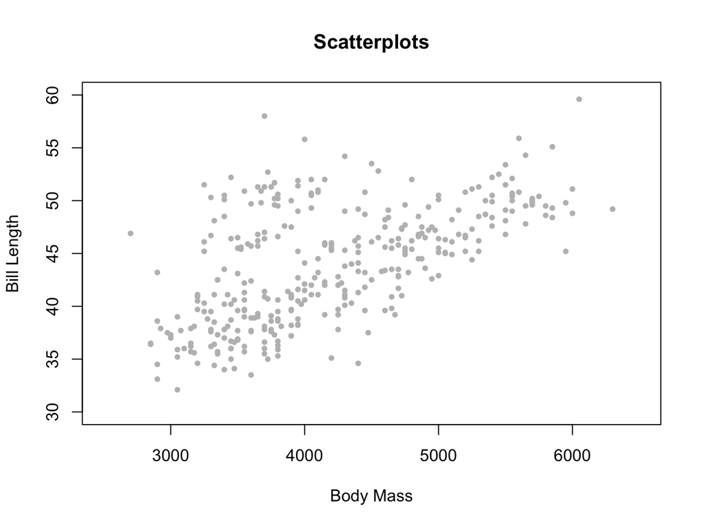

```r
plot <- plot(bill_length_mm  ~ body_mass_g,
     data=penguins,
     pch = 16,
     col=16,
     cex = .75,
     xlab = 'Body Mass',
     ylab = 'Bill Length',
     main = 'Scatterplots',
     xlim = c(2500, 6500),
     ylim =  c(30, 60))
```

## `boxplot()`

I can use the `boxplot()` function to create a boxplot of the data. This will show the spread and quartiles of the data, as well as any outliers, however it may be difficult for inexperienced people to interpret.

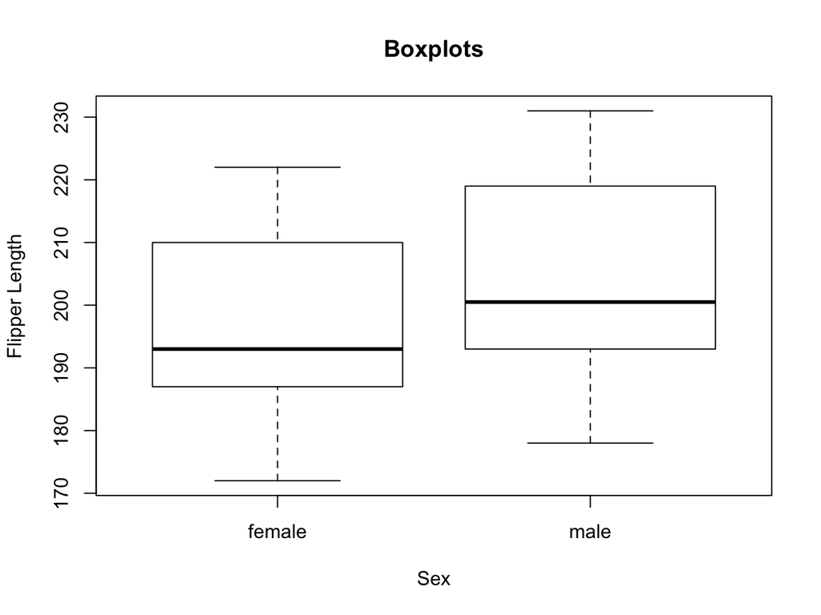

```r
boxplot <- boxplot(penguins$flipper_length_mm~penguins$sex,
        ylab = 'Flipper Length',
        xlab = 'Sex',
        main = 'Boxplots')
```

## `hist()`

If I want to create a histogram, I can use the `hist()` function.

- If I want to change the number of bins, I can use the breaks parameter. But beware, R might be sneaky and create a different number of bins if the number cannot accurately represent the data. (Imagine it as a suggestion, rather than a demand.)

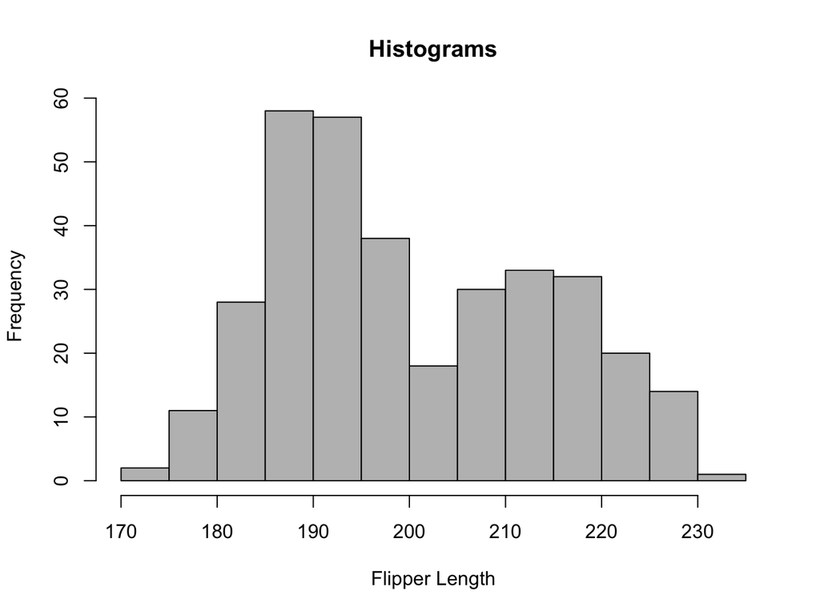

```r
#Letting  R decide how many breaks to use
histogram_1 <- hist(penguins$flipper_length_mm, col=16, xlab='Flipper Length', main='Histograms')
```

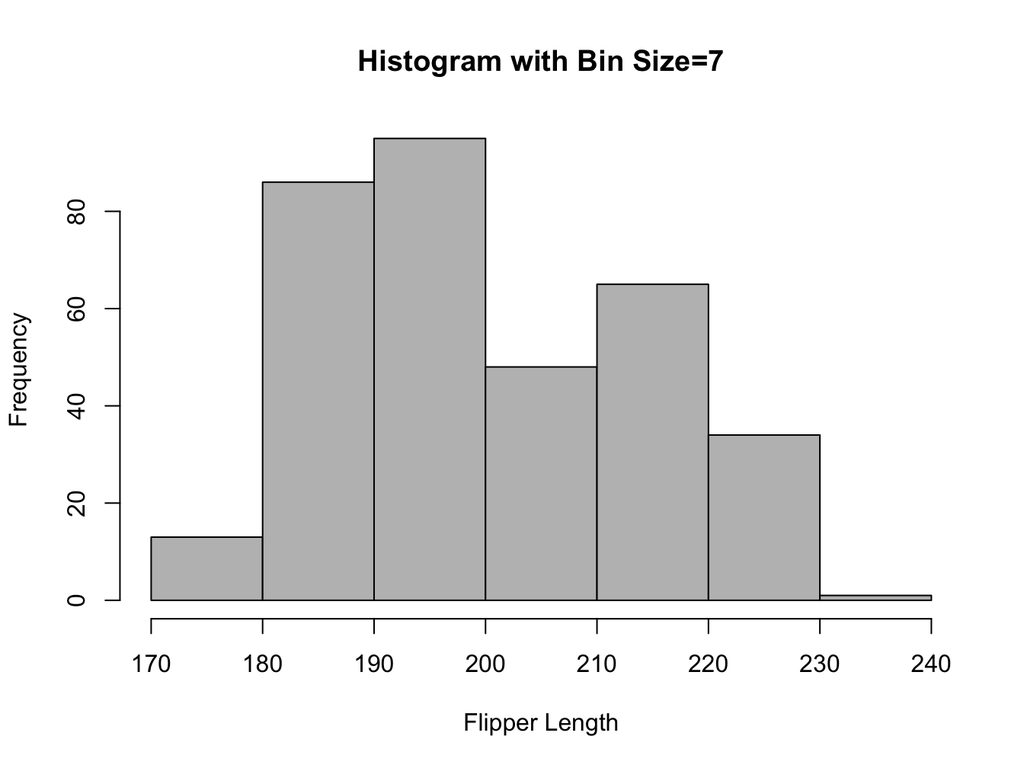

```r
#Suggesting a specific number of breaks
histogram_2 <- hist(penguins$flipper_length_mm, col=16, breaks=7, xlab='Flipper Length', main = 'Histogram with Bin Size=7')
```

## `par()` and `mfrow=`

The `par()` function allows you to inspect the graphical parameters. It returns a number of different things, like the parameters of the axes, the default shapes drawn, and the spread of the data. If you’re curious about what sorts of things `par()` returns, use the [`?par()`](https://www.rdocumentation.org/packages/graphics/versions/3.6.2/topics/par) function to see the documentation.

The parameter `mfrow=` can be used if you want to display multiple plots on one display. It is useful if you need to make side-by-side comparisons, especially if there is at least one shared variable between the graphs.

```r
par()
```

[output not shown]

[output cut: 160 more lines]

[output not shown]

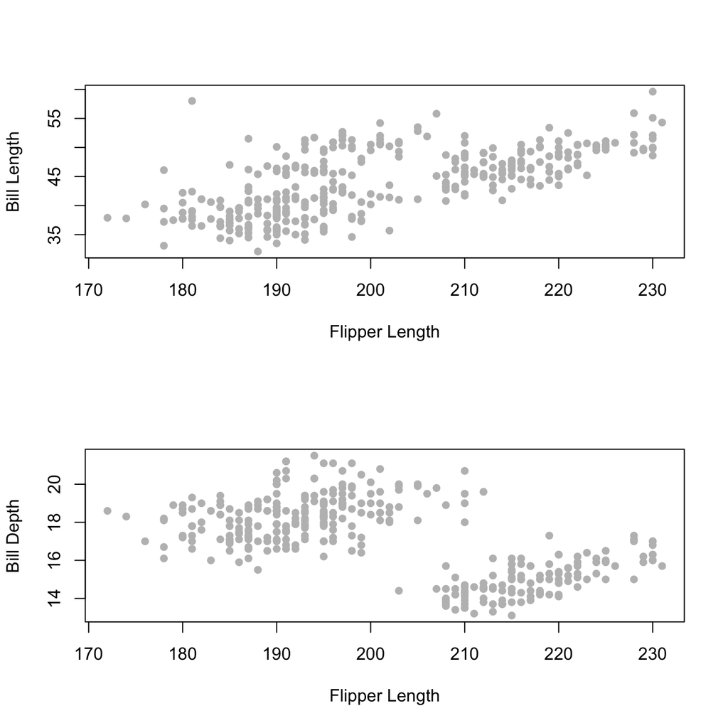

```r
?par
par(mfrow=c(2,1))

#For this example, I will show the difference between Bill Length and Bill Depth when compared against flipper length.
plot(penguins$bill_length_mm~penguins$flipper_length_mm, pch=16, xlab='Flipper Length', ylab='Bill Length', col=16)
plot(penguins$bill_depth_mm~penguins$flipper_length_mm, pch=16, xlab='Flipper Length', ylab='Bill Depth', col=16)
```

# Functions 4: Distribution Functions

## `dnorm()`

`dnorm()` gives the **density function** for the normal distribution. It indicates the probability of observing a measurement with a specific value. If you want to lean more, look at this [documentation](https://www.datascienceblog.net/post/basic-statistics/distributions/), or run `?dnorm`.

The result is the probability of picking a value with those specifications.

```r
dnorm(c(1,2,3,4,5), mean = 0, sd = 1, log=FALSE)
```

```
## [1] 2.419707e-01 5.399097e-02 4.431848e-03 1.338302e-04 1.486720e-06
```

## `pnorm()`

`pnorm()` gives the **cumulative density function** for the normal distribution. This means the probability of picking a value equal than or lesser to another value at random. If you compute it over multiple values, it is *monotonically increasing*. The first parameter is the number or vector you want to find the probability for, the second is the mean of the distribution, and the third is the standard deviation.

The result is the probability of picking that value or any value less than it with those specifications.

```r
pnorm(2, mean = 2.5, sd=.5)
```

```
## [1] 0.1586553
```

## `qnorm()`

`qnorm()` gives the **quantile function** for the normal distribution, which is the inverse of the cumulative density function (found with `pnorm()`). The first parameter is the probability, the second is the mean, and the third is the standard deviation. If you want to learn more, see [this website](https://homerhanumat.github.io/tigerstats/qnorm.html)

The result is the value that would have that probability of picking it and all values less than it.

```r
qnorm(.12, mean = 10, sd=1)
```

```
## [1] 8.825013
```

## `dbinom()`

`dbinom()` gives the **density function** for the binomial distribution. It is similar to `dnorm()`. but it is *not* for the normal distribution. It can be thought of as the number of successes in a number of trials. The first parameter is the vector of quantities that you are looking for. In other words, it is the hypothetical number of successes. The second is the size of the dataset. The size is the number of trials and the prob is the probability of success. Use log=TRUE if you are using boolean values. The result is the probability of success for each number in the vectors.

```r
dbinom(c(1,2,3,4,5), size=10, prob=.10, log=FALSE)
```

```
## [1] 0.387420489 0.193710244 0.057395628 0.011160261 0.001488035
```

## `pbinom()`

`pbinom()` gives the **cumulative probability function** for the binomial distribution. This can be thought of as the probability of having up to a certain number of successes. The first parameter is the data or vector of data, then there is the size (number of trials), and the probability of success on each trial. If you are working with logical values, use `log.p = TRUE`, othewise set it to `FALSE` or leave it out.

```r
pbinom(c(1,2,3,4,5), size = 10, prob=.10)
```

```
## [1] 0.7360989 0.9298092 0.9872048 0.9983651 0.9998531
```

## `qbinom()`

`qbinom()` returns the inverse of the cumulative density function for the binomial distribution. In other words, it returns the number of successes that is associated with the probability of success and the other parameters.

```r
qbinom(0.9, size = 10, prob=.10)
```

```
## [1] 2
```

# Functions 5: Other Functions

See the final project description for a list of the required functions.

## `subset()`

The subset function is useful if you have specific parameters for data that you need in a column. It allows for a lot of freedom while subsetting.

```r
subset(penguins,  body_mass_g < 4000)
```

```
## # A tibble: 165 x 8
##    species island bill_length_mm bill_depth_mm flipper_length_… body_mass_g
##    <fct>   <fct>           <dbl>         <dbl>            <int>       <int>
##  1 Adelie  Torge…           39.1          18.7              181        3750
##  2 Adelie  Torge…           39.5          17.4              186        3800
##  3 Adelie  Torge…           40.3          18                195        3250
##  4 Adelie  Torge…           36.7          19.3              193        3450
##  5 Adelie  Torge…           39.3          20.6              190        3650
##  6 Adelie  Torge…           38.9          17.8              181        3625
##  7 Adelie  Torge…           34.1          18.1              193        3475
##  8 Adelie  Torge…           37.8          17.1              186        3300
##  9 Adelie  Torge…           37.8          17.3              180        3700
## 10 Adelie  Torge…           41.1          17.6              182        3200
## # … with 155 more rows, and 2 more variables: sex <fct>, year <int>
```

## `library()`

The library function loads a data packages. It is how you can get data into the working directory. If the package has not been installed beforehand, however, it will not execute. If you are confused about the difference between `library()` and `require()` see this [site](https://yihui.org/en/2014/07/library-vs-require/).

```r
library(palmerpenguins)
head(penguins)
```

```
## # A tibble: 6 x 8
##   species island bill_length_mm bill_depth_mm flipper_length_… body_mass_g
##   <fct>   <fct>           <dbl>         <dbl>            <int>       <int>
## 1 Adelie  Torge…           39.1          18.7              181        3750
## 2 Adelie  Torge…           39.5          17.4              186        3800
## 3 Adelie  Torge…           40.3          18                195        3250
## 4 Adelie  Torge…           NA            NA                 NA          NA
## 5 Adelie  Torge…           36.7          19.3              193        3450
## 6 Adelie  Torge…           39.3          20.6              190        3650
## # … with 2 more variables: sex <fct>, year <int>
```

## `require()`

The require funciton is another way to load data packages into the working directory. This function will try to load the data, but if it is not installed, it will not create an error until the data is called later. If you are confused about the difference between `library()` and `require()` see this [site](https://yihui.org/en/2014/07/library-vs-require/).

```r
require(palmerpenguins)
head(penguins)
```

```
## # A tibble: 6 x 8
##   species island bill_length_mm bill_depth_mm flipper_length_… body_mass_g
##   <fct>   <fct>           <dbl>         <dbl>            <int>       <int>
## 1 Adelie  Torge…           39.1          18.7              181        3750
## 2 Adelie  Torge…           39.5          17.4              186        3800
## 3 Adelie  Torge…           40.3          18                195        3250
## 4 Adelie  Torge…           NA            NA                 NA          NA
## 5 Adelie  Torge…           36.7          19.3              193        3450
## 6 Adelie  Torge…           39.3          20.6              190        3650
## # … with 2 more variables: sex <fct>, year <int>
```

## `read.csv()`

The `read.csv()` function is another way to read data into the working directory. The file needs to be installed on your device first, however. You can use a file path (relative to the working directory).

```r
#The following code is relative to the Docs folder
delomy_data <- read.csv('../data/delomys.csv')
head(delomy_data)
```

```
##       X   genus         binomial body_mass body_length   age    sex
## 1 27526 Delomys Delomys dorsalis      50.5         259 adult female
## 2 27528 Delomys Delomys dorsalis      79.0         223 adult female
## 3 27529 Delomys Delomys dorsalis      57.0         206 adult female
## 4 27530 Delomys Delomys dorsalis      71.0         229 adult   male
## 5 27533 Delomys Delomys dorsalis      56.0         105 adult   male
## 6 27534 Delomys Delomys dorsalis      50.0         118 adult   male
##   longitude  latitude status
## 1 -48.22950 -24.20256  alive
## 2 -48.22950 -24.20256  alive
## 3 -48.22950 -24.20256  alive
## 4 -48.22950 -24.20256  alive
## 5 -50.39215 -29.40807  alive
## 6 -50.39215 -29.40807   dead
```

# Part 2: Data Anaylsis

Shapiro-Wilk’s

```r
delomys <- read.csv('../data/delomys.csv')
summary(delomys)
```

```
##        X             genus                     binomial
##  Min.   :27526   Delomys:1585   Delomys dorsalis   :1030
##  1st Qu.:27950                  Delomys sublineatus: 555
##  Median :28348
##  Mean   :28371
##  3rd Qu.:28790
##  Max.   :35552
##    body_mass       body_length          age           sex
##  Min.   :  5.00   Min.   : 49.0   adult   :1135   female:785
##  1st Qu.: 35.00   1st Qu.:106.0   juvenile: 135   male  :795
##  Median : 43.00   Median :116.0   NA's    : 315   NA's  :  5
##  Mean   : 44.06   Mean   :114.7
##  3rd Qu.: 54.00   3rd Qu.:124.0
##  Max.   :105.00   Max.   :265.0
##    longitude            latitude           status
##  Min.   :-49681671   Min.   :-22383667   alive:1451
##  1st Qu.:      -50   1st Qu.:      -29   dead : 134
##  Median :      -50   Median :      -29
##  Mean   :   -62739   Mean   :   -28272
##  3rd Qu.:      -47   3rd Qu.:      -24
##  Max.   :      -41   Max.   :      -20
```

```r
shapiro.test(delomys$body_mass)
```

```
##
##  Shapiro-Wilk normality test
##
## data:  delomys$body_mass
## W = 0.99506, p-value = 4.33e-05
```

```r
shapiro.test(delomys$body_length)
```

```
##
##  Shapiro-Wilk normality test
##
## data:  delomys$body_length
## W = 0.87609, p-value < 2.2e-16
```

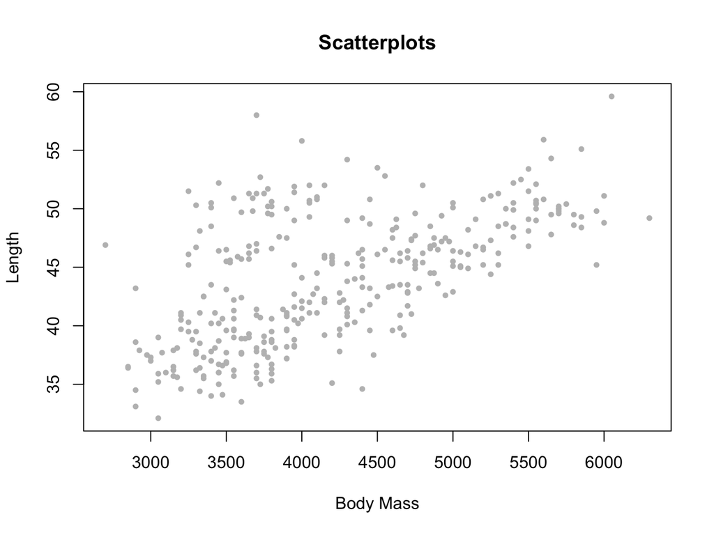

```r
plot <- plot(bill_length_mm ~ body_mass_g,
     col=16,
     data=penguins,
     pch = 16,
     cex = .75,
     xlab = 'Body Mass',
     ylab = 'Length',
     main = 'Scatterplots')
```

A histogram of body mass

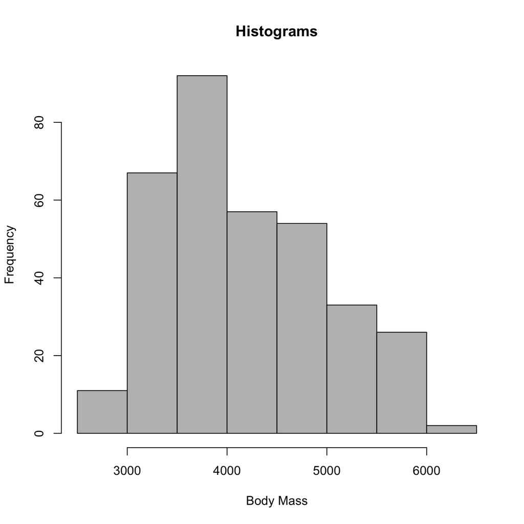

```r
histogram_2 <- hist(penguins$body_mass_g,
  col=16,
  xlab='Body Mass',
  main='Histograms')
```

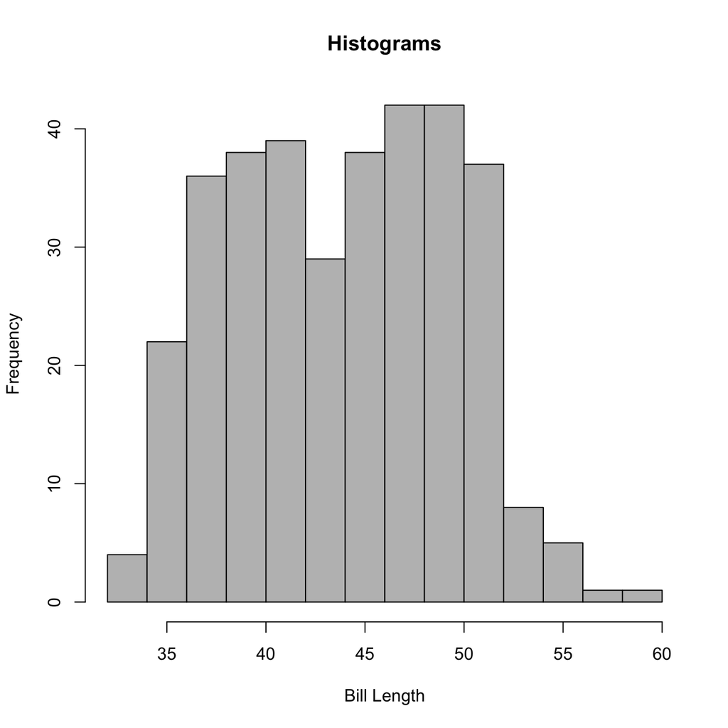

```r
histogram_3 <- hist(penguins$bill_length_mm,
  col=16,
  xlab='Bill Length',
  main='Histograms')
```

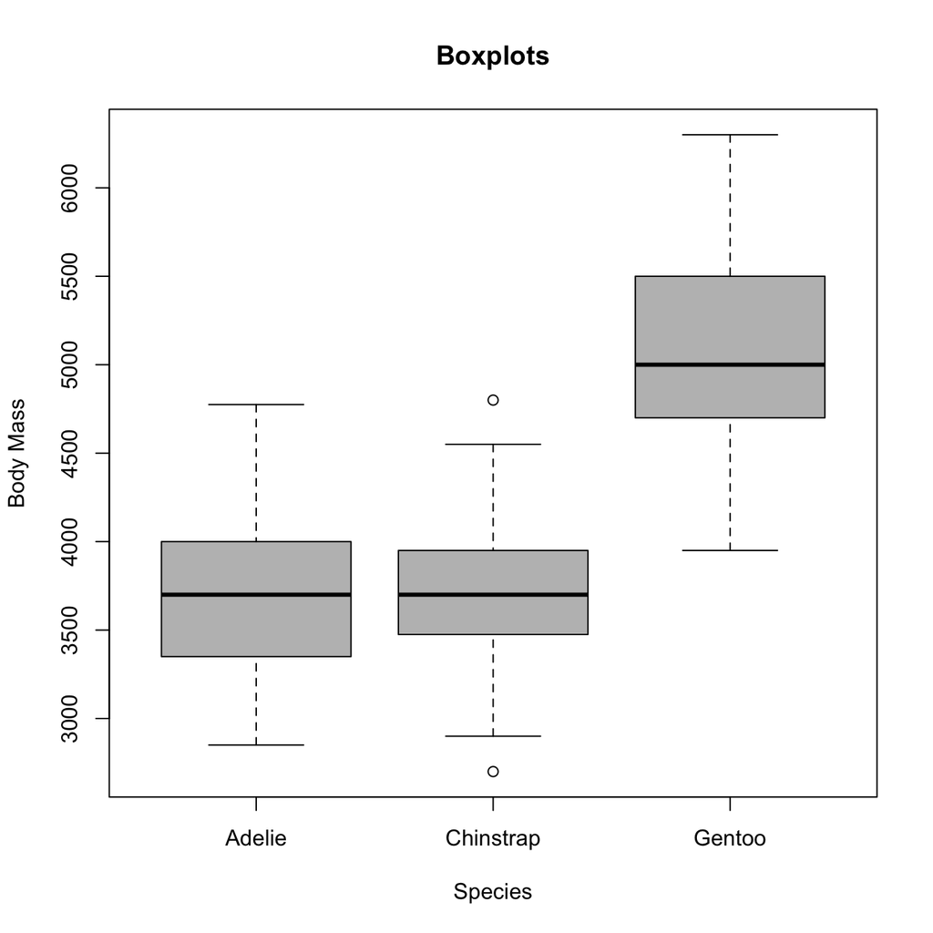

```r
boxplot_2 <- boxplot(body_mass_g~species,
        data = penguins,
        ylab = 'Body Mass',
        xlab = 'Species',
        main = 'Boxplots',
        col = 16)
```

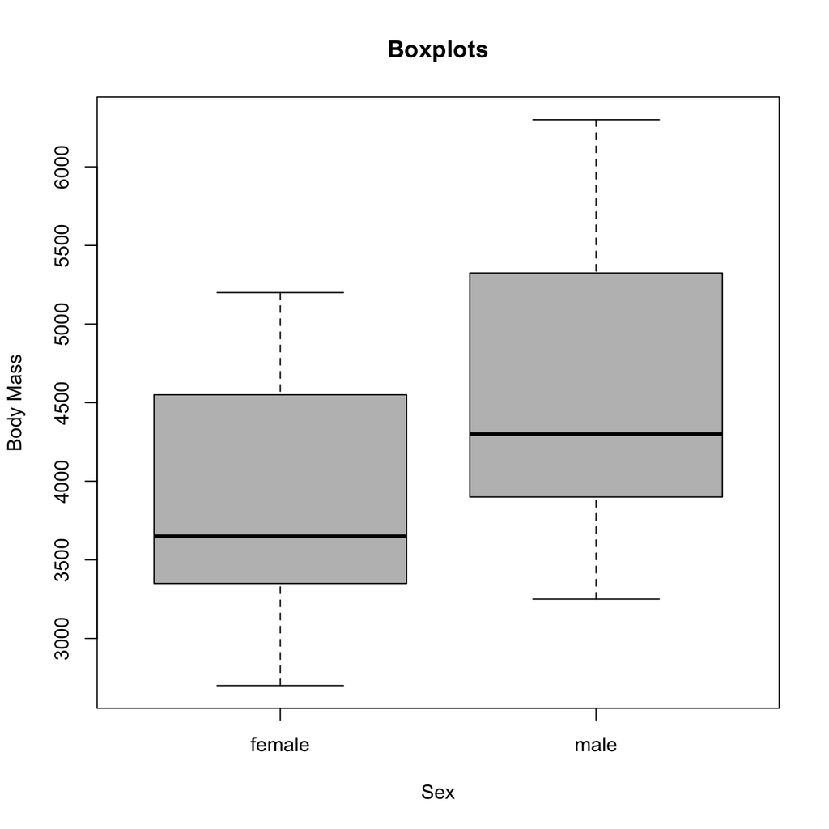

```r
boxplot<- boxplot(body_mass_g~sex,
        data = penguins,
        ylab = 'Body Mass',
        xlab = 'Sex',
        main = 'Boxplots',
        col=16)
```

A conditional boxplot of body mass, conditioned on both species and sex

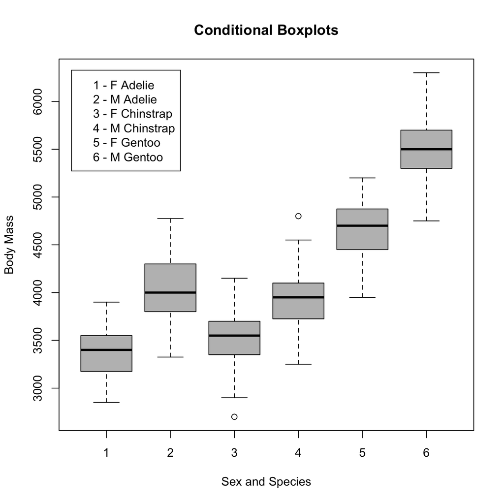

```r
# create the boxplot
boxplot(body_mass_g ~ sex + species,
        data = penguins,
        xlab = 'Sex and Species',
        ylab = 'Body Mass',
        main = 'Conditional Boxplots',
        names = list('1','2','3','4','5','6'),
        col=16)
# create a legend for the boxplot
legend("topleft", inset =  .03, legend= c('1 - F Adelie', '2 - M Adelie', '3 - F Chinstrap', '4 - M Chinstrap', '5 - F Gentoo', '6 - M Gentoo'), box.lty = 1)
```

## Questions

#### Qualitatively describe the relationship between body mass and length. Does the relationship seem linear, curved, nonexistent?

When not accounting for species differentiation, the relationship between body mass and length seems mostly linear with a positive slope. It could also be interprested as slightly concave down, increasing. There are a few points with a high length, and these likely correspond to one specific species.

#### Qualitatively describe the shapes of the histograms. Do the data appear normally-distributed? Explain why or why not.

The histogram of body mass appears to be skewed right slightly. The mode is aroung 3500, which is sharply decreasing to the left side. However, looking at the right side, the frequency diminishes more gradually.

#### Using both the histograms and normality tests, do you think the (unconditioned) body masses and body length are normally-distributed? Contrast your visual assessment of normality to the results of the numerical normality tests.

Since the p-value for the shapiro test on the body length is so low, I can conclude that the data is *not* normally distributed. The shapiro test on the body mass is also quite low, so I can conclude that that is also *not* normally distributed. From a visual inspection, I can see how this is the case, since both histograms have elements that make me doubt the normality..

### Model Building Questions

```r
# Model 1: simple linear regression
fit1 <- lm(body_length ~ body_mass, data = delomys)

# Model 2: 1-way anova
fit2 <- lm(body_mass ~ sex,  data = delomys)

# Model 3: 1-way anova
fit3 <- lm(body_mass ~ binomial, data = delomys)

# Model 4: 2-way additive ANOVA
fit4 <- lm(body_mass ~ sex + binomial, data = delomys)

# Model 5: 2-way factorial ANOVA
fit5 <- lm(body_mass ~ sex * binomial, data = delomys)
```

### Model Diagnostics

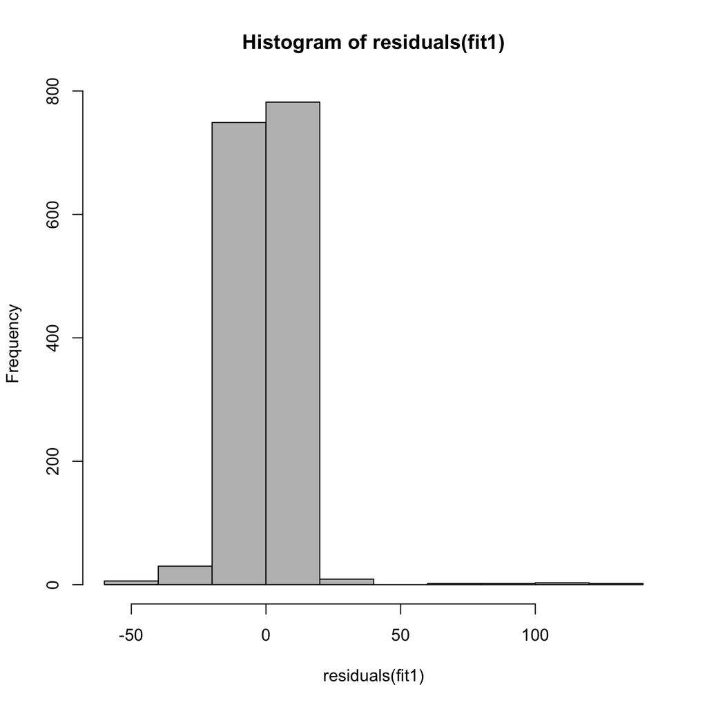

```r
#Plotting Histograms of Residual and shapiro test
hist(residuals(fit1), col=16)
```

```r
shapiro.test(residuals(fit1))
```

```
##
##  Shapiro-Wilk normality test
##
## data:  residuals(fit1)
## W = 0.73462, p-value < 2.2e-16
```

```r
summary(fit1)
```

```
##
## Call:
## lm(formula = body_length ~ body_mass, data = delomys)
##
## Residuals:
##     Min      1Q  Median      3Q     Max
## -48.888  -5.398   0.104   4.859 138.663
##
## Coefficients:
##             Estimate Std. Error t value Pr(>|t|)
## (Intercept) 76.12466    0.91581   83.12   <2e-16 ***
## body_mass    0.87550    0.01969   44.46   <2e-16 ***
## ---
## Signif. codes:  0 '***' 0.001 '**' 0.01 '*' 0.05 '.' 0.1 ' ' 1
##
## Residual standard error: 11.67 on 1583 degrees of freedom
## Multiple R-squared:  0.5553, Adjusted R-squared:  0.5551
## F-statistic:  1977 on 1 and 1583 DF,  p-value: < 2.2e-16
```

```r
knitr::kable(coef(summary(fit1)))
```

|  | Estimate | Std. Error | t value | Pr(>\|t\|) |
| --- | --- | --- | --- | --- |
| (Intercept) | 76.1246565 | 0.9158120 | 83.12258 | 0 |
| body_mass | 0.8754988 | 0.0196905 | 44.46298 | 0 |

```r
knitr::kable(anova(fit1))
```

|  | Df | Sum Sq | Mean Sq | F value | Pr(>F) |
| --- | --- | --- | --- | --- | --- |
| body_mass | 1 | 269388.9 | 269388.9086 | 1976.957 | 0 |
| Residuals | 1583 | 215706.6 | 136.2645 | NA | NA |

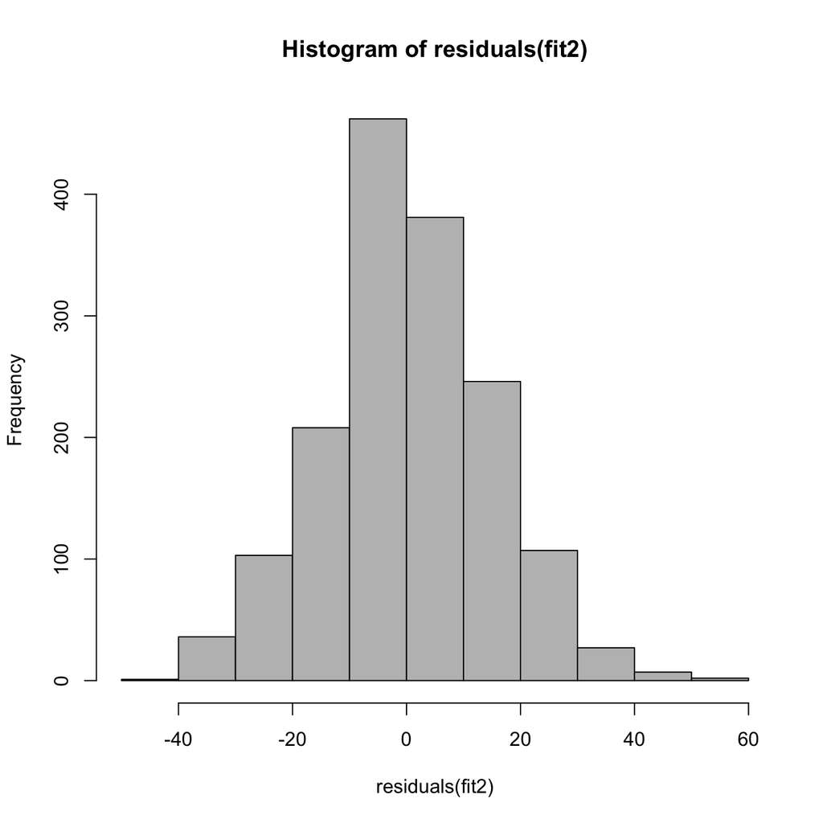

```r
hist(residuals(fit2), col=16)
```

```r
shapiro.test(residuals(fit2))
```

```
##
##  Shapiro-Wilk normality test
##
## data:  residuals(fit2)
## W = 0.99563, p-value = 0.0001541
```

```r
summary(fit2)
```

```
##
## Call:
## lm(formula = body_mass ~ sex, data = delomys)
##
## Residuals:
##     Min      1Q  Median      3Q     Max
## -40.496  -8.711  -0.496   9.504  59.504
##
## Coefficients:
##             Estimate Std. Error t value Pr(>|t|)
## (Intercept)  42.7115     0.5289  80.756  < 2e-16 ***
## sexmale       2.7841     0.7456   3.734 0.000195 ***
## ---
## Signif. codes:  0 '***' 0.001 '**' 0.01 '*' 0.05 '.' 0.1 ' ' 1
##
## Residual standard error: 14.82 on 1578 degrees of freedom
##   (5 observations deleted due to missingness)
## Multiple R-squared:  0.008758,   Adjusted R-squared:  0.00813
## F-statistic: 13.94 on 1 and 1578 DF,  p-value: 0.0001951
```

```r
knitr::kable(coef(summary(fit2)))
```

|  | Estimate | Std. Error | t value | Pr(>\|t\|) |
| --- | --- | --- | --- | --- |
| (Intercept) | 42.711465 | 0.5288929 | 80.756355 | 0.0000000 |
| sexmale | 2.784133 | 0.7456117 | 3.734024 | 0.0001951 |

```r
knitr::kable(anova(fit2))
```

|  | Df | Sum Sq | Mean Sq | F value | Pr(>F) |
| --- | --- | --- | --- | --- | --- |
| sex | 1 | 3061.678 | 3061.6779 | 13.94294 | 0.0001951 |
| Residuals | 1578 | 346507.131 | 219.5863 | NA | NA |

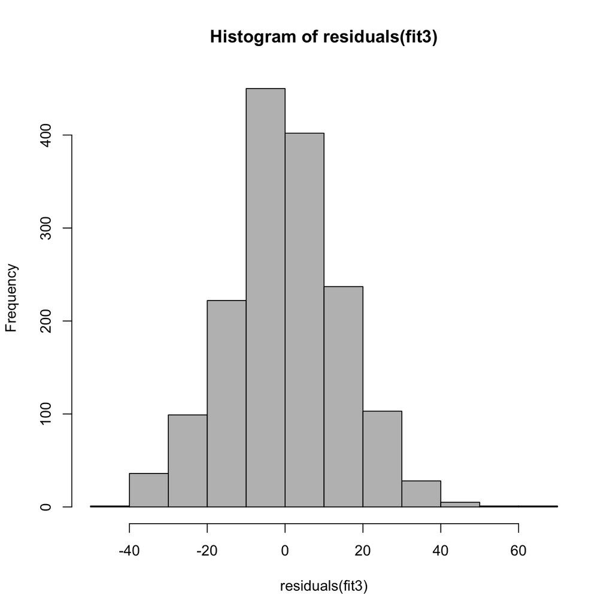

```r
hist(residuals(fit3), col=16)
```

```r
shapiro.test(residuals(fit3))
```

```
##
##  Shapiro-Wilk normality test
##
## data:  residuals(fit3)
## W = 0.99535, p-value = 8.103e-05
```

```r
summary(fit3)
```

```
##
## Call:
## lm(formula = body_mass ~ binomial, data = delomys)
##
## Residuals:
##     Min      1Q  Median      3Q     Max
## -41.752  -9.069  -0.069   9.248  65.931
##
## Coefficients:
##                             Estimate Std. Error t value Pr(>|t|)
## (Intercept)                  46.7524     0.4500   103.9   <2e-16 ***
## binomialDelomys sublineatus  -7.6831     0.7605   -10.1   <2e-16 ***
## ---
## Signif. codes:  0 '***' 0.001 '**' 0.01 '*' 0.05 '.' 0.1 ' ' 1
##
## Residual standard error: 14.44 on 1583 degrees of freedom
## Multiple R-squared:  0.06058,    Adjusted R-squared:  0.05998
## F-statistic: 102.1 on 1 and 1583 DF,  p-value: < 2.2e-16
```

```r
knitr::kable(coef(summary(fit3)))
```

|  | Estimate | Std. Error | t value | Pr(>\|t\|) |
| --- | --- | --- | --- | --- |
| (Intercept) | 46.752427 | 0.4499933 | 103.89582 | 0 |
| binomialDelomys sublineatus | -7.683058 | 0.7604562 | -10.10322 | 0 |

```r
knitr::kable(anova(fit3))
```

|  | Df | Sum Sq | Mean Sq | F value | Pr(>F) |
| --- | --- | --- | --- | --- | --- |
| binomial | 1 | 21289.68 | 21289.6805 | 102.0751 | 0 |
| Residuals | 1583 | 330164.45 | 208.5688 | NA | NA |

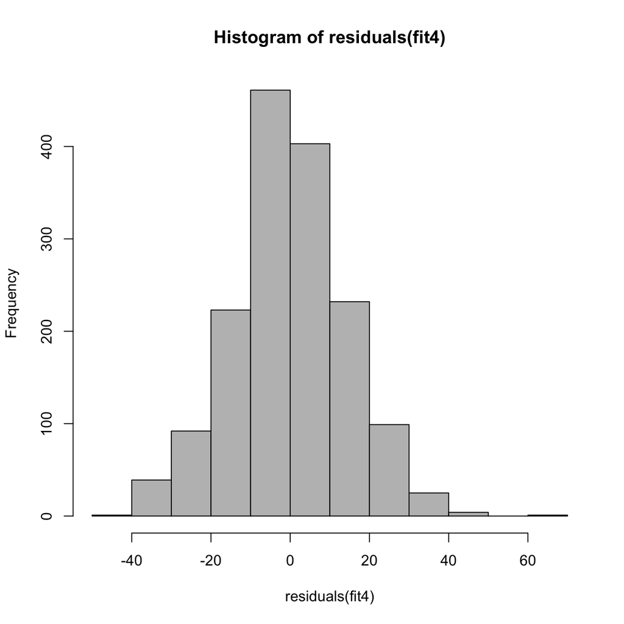

```r
hist(residuals(fit4), col=16)
```

```r
shapiro.test(residuals(fit4))
```

```
##
##  Shapiro-Wilk normality test
##
## data:  residuals(fit4)
## W = 0.99525, p-value = 6.805e-05
```

```r
summary(fit4)
```

```
##
## Call:
## lm(formula = body_mass ~ sex + binomial, data = delomys)
##
## Residuals:
##     Min      1Q  Median      3Q     Max
## -43.866  -8.866  -0.672   8.930  64.328
##
## Coefficients:
##                             Estimate Std. Error t value Pr(>|t|)
## (Intercept)                  45.0704     0.5556  81.114  < 2e-16 ***
## sexmale                       3.7954     0.7260   5.228 1.94e-07 ***
## binomialDelomys sublineatus  -8.1935     0.7610 -10.767  < 2e-16 ***
## ---
## Signif. codes:  0 '***' 0.001 '**' 0.01 '*' 0.05 '.' 0.1 ' ' 1
##
## Residual standard error: 14.31 on 1577 degrees of freedom
##   (5 observations deleted due to missingness)
## Multiple R-squared:  0.07663,    Adjusted R-squared:  0.07546
## F-statistic: 65.44 on 2 and 1577 DF,  p-value: < 2.2e-16
```

```r
knitr::kable(coef(summary(fit4)))
```

|  | Estimate | Std. Error | t value | Pr(>\|t\|) |
| --- | --- | --- | --- | --- |
| (Intercept) | 45.070355 | 0.5556429 | 81.113891 | 0e+00 |
| sexmale | 3.795395 | 0.7259609 | 5.228099 | 2e-07 |
| binomialDelomys sublineatus | -8.193492 | 0.7609985 | -10.766764 | 0e+00 |

```r
knitr::kable(anova(fit4))
```

|  | Df | Sum Sq | Mean Sq | F value | Pr(>F) |
| --- | --- | --- | --- | --- | --- |
| sex | 1 | 3061.678 | 3061.6779 | 14.95838 | 0.0001144 |
| binomial | 1 | 23727.134 | 23727.1342 | 115.92320 | 0.0000000 |
| Residuals | 1577 | 322779.997 | 204.6798 | NA | NA |

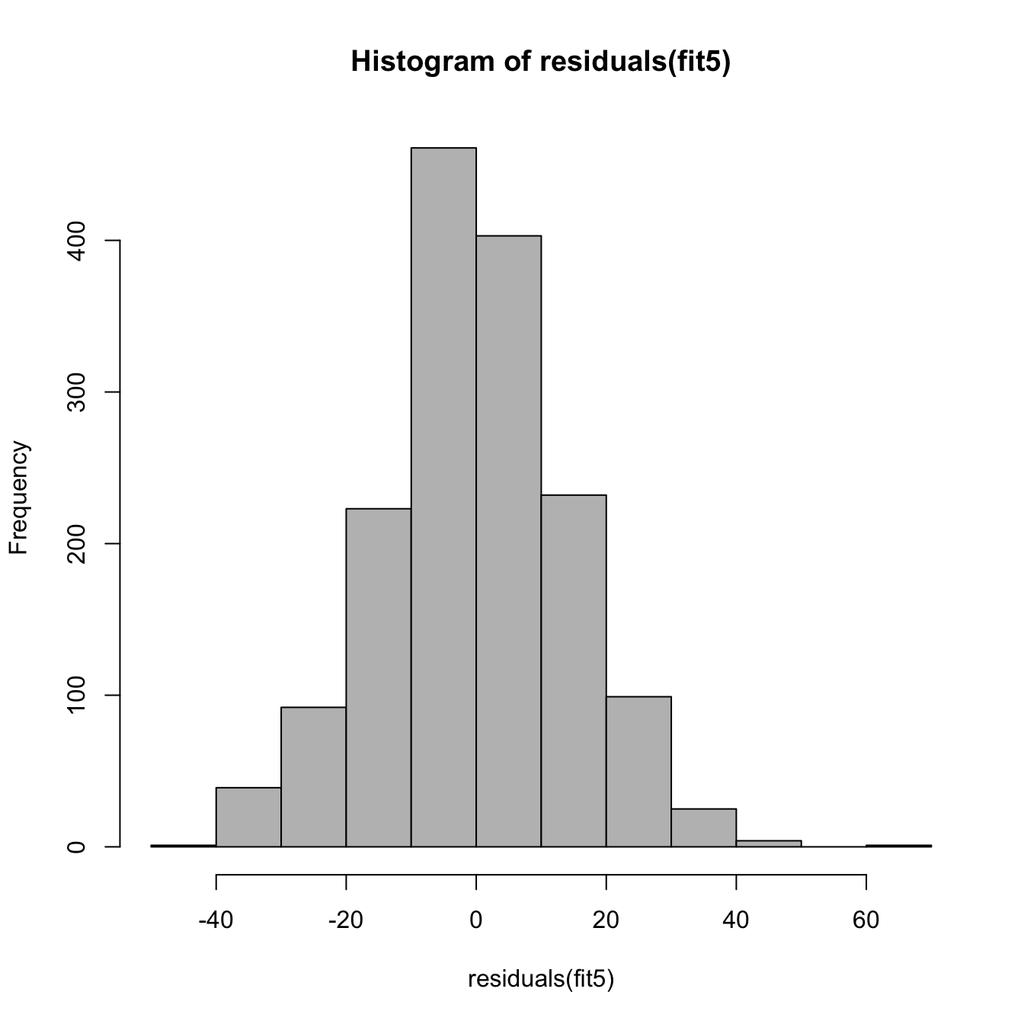

```r
hist(residuals(fit5), col=16)
```

```r
shapiro.test(residuals(fit5))
```

```
##
##  Shapiro-Wilk normality test
##
## data:  residuals(fit5)
## W = 0.99526, p-value = 6.816e-05
```

```r
summary(fit5)
```

```
##
## Call:
## lm(formula = body_mass ~ sex * binomial, data = delomys)
##
## Residuals:
##     Min      1Q  Median      3Q     Max
## -43.884  -8.884  -0.647   8.945  64.353
##
## Coefficients:
##                                     Estimate Std. Error t value Pr(>|t|)
## (Intercept)                         45.05546    0.60530  74.435  < 2e-16
## sexmale                              3.82809    0.89667   4.269 2.08e-05
## binomialDelomys sublineatus         -8.14174    1.12810  -7.217 8.22e-13
## sexmale:binomialDelomys sublineatus -0.09502    1.52859  -0.062     0.95
##
## (Intercept)                         ***
## sexmale                             ***
## binomialDelomys sublineatus         ***
## sexmale:binomialDelomys sublineatus
## ---
## Signif. codes:  0 '***' 0.001 '**' 0.01 '*' 0.05 '.' 0.1 ' ' 1
##
## Residual standard error: 14.31 on 1576 degrees of freedom
##   (5 observations deleted due to missingness)
## Multiple R-squared:  0.07664,    Adjusted R-squared:  0.07488
## F-statistic:  43.6 on 3 and 1576 DF,  p-value: < 2.2e-16
```

```r
knitr::kable(coef(summary(fit5)))
```

|  | Estimate | Std. Error | t value | Pr(>\|t\|) |
| --- | --- | --- | --- | --- |
| (Intercept) | 45.0554562 | 0.6052973 | 74.4352459 | 0.0000000 |
| sexmale | 3.8280908 | 0.8966667 | 4.2692460 | 0.0000208 |
| binomialDelomys sublineatus | -8.1417394 | 1.1281046 | -7.2171847 | 0.0000000 |
| sexmale:binomialDelomys sublineatus | -0.0950187 | 1.5285856 | -0.0621612 | 0.9504424 |

```r
knitr::kable(anova(fit5))
```

|  | Df | Sum Sq | Mean Sq | F value | Pr(>F) |
| --- | --- | --- | --- | --- | --- |
| sex | 1 | 3.061678e+03 | 3.061678e+03 | 14.948932 | 0.0001150 |
| binomial | 1 | 2.372713e+04 | 2.372713e+04 | 115.849977 | 0.0000000 |
| sex:binomial | 1 | 7.913846e-01 | 7.913846e-01 | 0.003864 | 0.9504424 |
| Residuals | 1576 | 3.227792e+05 | 2.048091e+02 | NA | NA |

#### What do you conclude about residual normality based on the numerical and graphical diagnostics?

Based on the results of the residual test, I can conclude that none of the residual models are normally distributed. From the shapiro test, I can see that the p-value is quite low, suggesting that I can reject the null hypothesis that they would be normally distributed, and instead conclude that they are not. From a rough visual inspection, this is less obvious, however, when inspecting more closely, I can see how it is true.

#### Are violations of the normality assumption equally severe for all the models.

Violations of the normality assumption are the largest in fit1 (body length vs body mass), and the smallest in fit2 (body mass vs sex). Even in the body mass vs sex example, however, the p-value is small enough to reject the null hypothesis by a significant margin.

#### What is the magnitude of the mass/length relationship?

The magnitude of the mass/length relationship is 0.87550.

#### What is the expected body length of an an animal that weighs 100g?

The expected body length of an animal that weighs 100g is 163.67466 mm.

#### What is the expected body length of an animal that weighs 0g?

The expected body length of an animal that weighs 0g is 76.12466 mm.

#### What is the base level for sex?

The base level for sex is **female**.

#### What is the base level for binomial?

The base level for binomial is **Delomys Dorsalis**.

#### Which sex is heavier?

**Males** are heavier than females.

#### Which species is heavier?

**Delomys Dorsalis** are heavier than Delomys sublineatus.

#### Are sex and species significant predictors for body mass?

Yes, sex and species are significant predictors of body mass.